# Classification Trees & Ensemble Methods (Python Code)

In this notebook we present the Python code for all the R chunks in this Chapter.

## Setup

```python
import numpy as np
import pandas as pd
import matplotlib.pyplot as plt

from pathlib import Path
from sklearn.tree import DecisionTreeClassifier, plot_tree, export_text
from sklearn.ensemble import (
    BaggingClassifier,
    RandomForestClassifier,
    AdaBoostClassifier,
    GradientBoostingClassifier,
    GradientBoostingRegressor,
)
from sklearn.linear_model import LogisticRegression
from sklearn.model_selection import train_test_split
from sklearn.metrics import accuracy_score

# xgboost needs an OpenMP runtime (libomp / libgomp). If you do not have thin then skip it.
try:
    import xgboost as xgb
    HAS_XGBOOST = True
except Exception:
    xgb = None
    HAS_XGBOOST = False

plt.rcParams.update({
    "figure.figsize": (6, 4.5),
    "axes.grid": False,
})
```

```python
def decision_boundary(ax, predict_fn, xlim, ylim, n=201, colors=("darkorange", "darkblue")):
    """Shade predicted class on a 2-d grid and draw the 0.5 contour."""
    xx, yy = np.meshgrid(
        np.linspace(*xlim, n),
        np.linspace(*ylim, n),
    )
    grid = np.column_stack([xx.ravel(), yy.ravel()])
    zz = np.asarray(predict_fn(grid)).reshape(xx.shape)
    ax.contourf(xx, yy, zz, levels=[-0.5, 0.5, 1.5],
                colors=colors, alpha=0.18)
    ax.contour(xx, yy, zz, levels=[0.5], colors="black", linewidths=1)
    return xx, yy, zz
```

## Titanic Tree

We use the same Titanic data as in the R example:

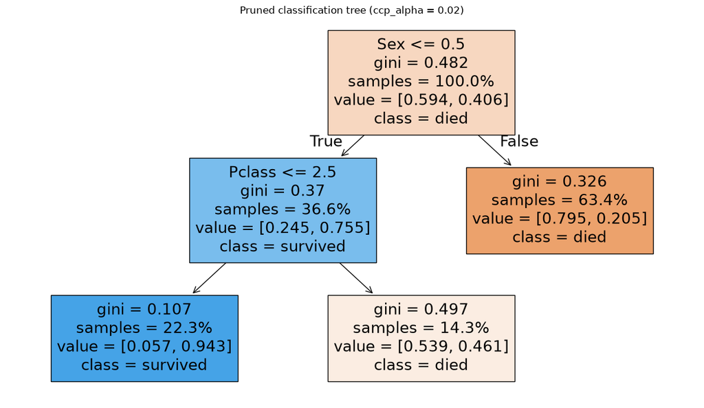

```
|--- Sex <= 0.50
|   |--- Pclass <= 2.50
|   |   |--- class: 1
|   |--- Pclass >  2.50
|   |   |--- class: 0
|--- Sex >  0.50
|   |--- class: 0
```

```python
DATA = Path("train.csv")

cols = ["Survived", "Pclass", "Sex", "Age", "SibSp", "Parch"]
titanic = pd.read_csv(DATA, usecols=cols)
titanic["Sex"] = (titanic["Sex"] == "male").astype(int)  # rpart dummy-codes this internally
titanic_cc = titanic.dropna(subset=cols).copy()

X_all = titanic_cc[["Pclass", "Sex", "Age", "SibSp", "Parch"]]
y_all = titanic_cc["Survived"].astype(int)

X_tr, X_te, y_tr, y_te = train_test_split(
    X_all, y_all, test_size=0.30, random_state=10, stratify=y_all
)

# Full-data tree (the rpart.plot figure)
tree_full = DecisionTreeClassifier(random_state=1, ccp_alpha=0.02)
tree_full.fit(X_all, y_all)

fig, ax = plt.subplots(figsize=(12, 7))
plot_tree(
    tree_full,
    feature_names=list(X_all.columns),
    class_names=["died", "survived"],
    filled=True,
    impurity=True,
    proportion=True,
    ax=ax,
)
ax.set_title("Pruned classification tree (ccp_alpha = 0.02)")
plt.tight_layout()
plt.show()

print(export_text(tree_full, feature_names=list(X_all.columns)))
```

```python
maj = int(y_tr.value_counts().idxmax())
base_err = np.mean(y_te.to_numpy() != maj)

tree_hold = DecisionTreeClassifier(random_state=1, ccp_alpha=0.02)
tree_hold.fit(X_tr, y_tr)
tree_err_tr = 1 - accuracy_score(y_tr, tree_hold.predict(X_tr))
tree_err_te = 1 - accuracy_score(y_te, tree_hold.predict(X_te))

logit = LogisticRegression(max_iter=1000)
logit.fit(X_tr, y_tr)
glm_err_te = 1 - accuracy_score(y_te, logit.predict(X_te))

pd.DataFrame({
    "method": [
        "Majority class (holdout)",
        "Pruned tree (train)",
        "Pruned tree (holdout)",
        "Logistic regression (holdout)",
    ],
    "misclassification": np.round(
        [base_err, tree_err_tr, tree_err_te, glm_err_te], 3
    ),
})
```

|  | method | misclassification |
| --- | --- | --- |
| 0 | Majority class (holdout) | 0.405 |
| 1 | Pruned tree (train) | 0.194 |
| 2 | Pruned tree (holdout) | 0.219 |
| 3 | Logistic regression (holdout) | 0.214 |

## Circle Simulation and a Single Tree

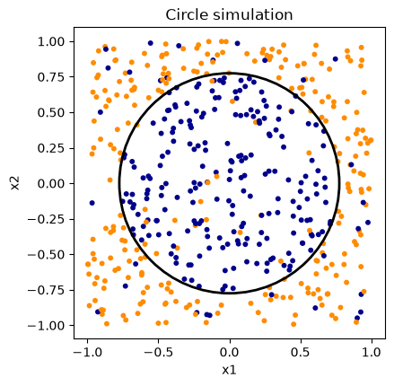

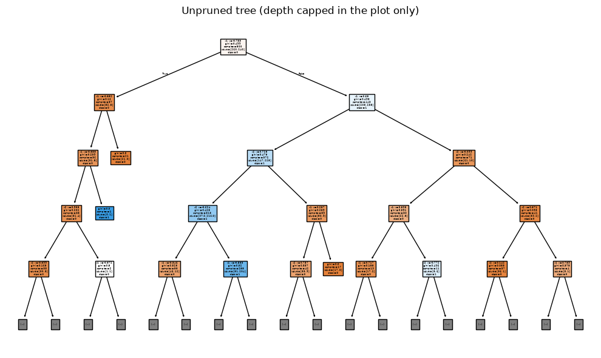

```python
rng = np.random.default_rng(1)
n = 500
x1 = rng.uniform(-1, 1, n)
x2 = rng.uniform(-1, 1, n)
p = np.where(x1**2 + x2**2 < 0.6, 0.9, 0.1)
y = rng.binomial(1, p)

fig, ax = plt.subplots()
ax.scatter(x1, x2, c=np.where(y == 1, "darkblue", "darkorange"), s=18, edgecolors="none")
circ = plt.Circle((0, 0), np.sqrt(0.6), fill=False, lw=2)
ax.add_patch(circ)
ax.set_aspect("equal", "box")
ax.set_xlabel("x1")
ax.set_ylabel("x2")
ax.set_title("Circle simulation")
plt.show()

X_circ = np.column_stack([x1, x2])
tree_circ = DecisionTreeClassifier(random_state=1)
tree_circ.fit(X_circ, y)

fig, ax = plt.subplots(figsize=(10, 6))
plot_tree(tree_circ, feature_names=["x1", "x2"], class_names=["0", "1"],
          filled=True, max_depth=4, ax=ax)
ax.set_title("Unpruned tree (depth capped in the plot only)")
plt.tight_layout()
plt.show()
```

Cost-complexity path (R: `rpart.fit$cptable`). Then prune at a chosen `ccp_alpha`. *Remark:* Do not copy a `cp` value from the R notes into `ccp_alpha`. `ccp_alpha` is the same *idea* as `rpart`'s `cp` (cost-complexity pruning)

```python
path = tree_circ.cost_complexity_pruning_path(X_circ, y)
cptable = pd.DataFrame({
    "ccp_alpha": path.ccp_alphas,
    "impurity_leaves": path.impurities,
})
cptable
```

|  | ccp_alpha | impurity_leaves |
| --- | --- | --- |
| 0 | 0.000000 | 0.000000 |
| 1 | 0.001500 | 0.003000 |
| 2 | 0.001714 | 0.006429 |
| 3 | 0.001771 | 0.020600 |
| 4 | 0.001786 | 0.024171 |
| 5 | 0.001810 | 0.031410 |
| 6 | 0.001818 | 0.038682 |
| 7 | 0.001846 | 0.042375 |
| 8 | 0.001857 | 0.046089 |
| 9 | 0.001857 | 0.053517 |
| 10 | 0.001867 | 0.060985 |
| 11 | 0.001882 | 0.064750 |
| 12 | 0.001897 | 0.072337 |
| 13 | 0.001900 | 0.076137 |
| 14 | 0.001902 | 0.083747 |
| 15 | 0.002000 | 0.089747 |
| 16 | 0.002012 | 0.093771 |
| 17 | 0.002037 | 0.097846 |
| 18 | 0.002390 | 0.112187 |
| 19 | 0.002400 | 0.116987 |
| 20 | 0.002400 | 0.121787 |
| 21 | 0.002400 | 0.124187 |
| 22 | 0.002497 | 0.129180 |
| 23 | 0.002667 | 0.134514 |
| 24 | 0.002829 | 0.143000 |
| 25 | 0.003126 | 0.146125 |
| 26 | 0.003200 | 0.149325 |
| 27 | 0.003333 | 0.152659 |
| 28 | 0.003500 | 0.156159 |
| 29 | 0.003579 | 0.163317 |
| 30 | 0.003955 | 0.171226 |
| 31 | 0.004345 | 0.179915 |
| 32 | 0.005352 | 0.201322 |
| 33 | 0.006199 | 0.219918 |
| 34 | 0.006341 | 0.226258 |
| 35 | 0.006824 | 0.239907 |
| 36 | 0.007088 | 0.246995 |
| 37 | 0.010683 | 0.268361 |
| 38 | 0.016029 | 0.284389 |
| 39 | 0.053703 | 0.499200 |

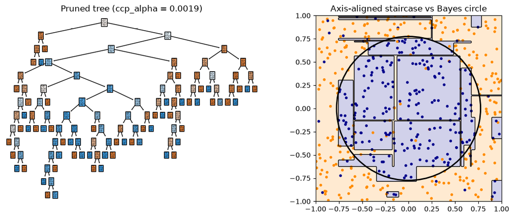

```python
# Pick an alpha near the R notes' idea of a small prune (not the same number as cp = 0.041)
alpha = path.ccp_alphas[max(0, len(path.ccp_alphas) // 3)]
pruned = DecisionTreeClassifier(random_state=1, ccp_alpha=alpha)
pruned.fit(X_circ, y)

fig, axes = plt.subplots(1, 2, figsize=(11, 4.5))
plot_tree(pruned, feature_names=["x1", "x2"], class_names=["0", "1"],
          filled=True, ax=axes[0])
axes[0].set_title(f"Pruned tree (ccp_alpha = {alpha:.4f})")

decision_boundary(axes[1], pruned.predict, (-1, 1), (-1, 1))
axes[1].scatter(x1, x2, c=np.where(y == 1, "darkblue", "darkorange"),
                s=16, edgecolors="none")
axes[1].add_patch(plt.Circle((0, 0), np.sqrt(0.6), fill=False, lw=2))
axes[1].set_aspect("equal", "box")
axes[1].set_title("Axis-aligned staircase vs Bayes circle")
plt.tight_layout()
plt.show()
```

## Impurity Measures

R defined `gini`, `shannon`, `error`, and the split gain `score`.

```python
def _freqs(y):
    y = np.asarray(y)
    _, counts = np.unique(y, return_counts=True)
    return counts / counts.sum()

def gini(y):
    p = _freqs(y)
    return float(np.sum(p * (1 - p)))

def shannon(y):
    p = _freqs(y)
    p = p[p > 0]
    return float(-np.sum(p * np.log(p)))

def misclass(y):
    p = _freqs(y)
    return float(1 - p.max())

def split_gain(left, right, measure):
    left, right = np.asarray(left), np.asarray(right)
    parent = np.concatenate([left, right])
    n_l, n_r = len(left), len(right)
    n = n_l + n_r
    return measure(parent) - (n_l / n) * measure(left) - (n_r / n) * measure(right)

TL = np.repeat(1, 3)
TR = np.array([1, 1, 1, 1, 0, 0, 0])
print("Gini gain     ", split_gain(TL, TR, gini))
print("Entropy gain  ", split_gain(TL, TR, shannon))
print("Error gain    ", split_gain(TL, TR, misclass))
```

```
Gini gain      0.07714285714285724
Entropy gain   0.13282862876456336
Error gain     5.551115123125783e-17
```

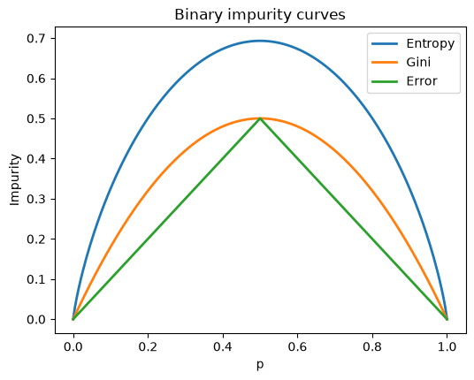

```python
p = np.linspace(0, 1, 201)
g = 2 * p * (1 - p)
s = np.zeros_like(p)
mid = (p > 0) & (p < 1)
s[mid] = -p[mid] * np.log(p[mid]) - (1 - p[mid]) * np.log(1 - p[mid])
e = np.minimum(p, 1 - p)

plt.plot(p, s, lw=2, label="Entropy")
plt.plot(p, g, lw=2, label="Gini")
plt.plot(p, e, lw=2, label="Error")
plt.xlabel("p")
plt.ylabel("Impurity")
plt.legend()
plt.title("Binary impurity curves")
plt.show()
```

## Bagging vs One Tree (diagonal strip)

R: `rpart` vs `ipred::bagging(..., nbagg = 200)`.

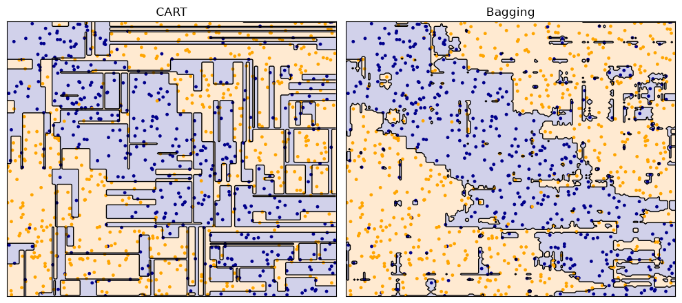

```python
rng = np.random.default_rng(2)
n = 1000
x1 = rng.uniform(-1, 1, n)
x2 = rng.uniform(-1, 1, n)
inside = (x1 + x2 > -0.5) & (x1 + x2 < 0.5)
y = rng.binomial(1, np.where(inside, 0.8, 0.2))
X = np.column_stack([x1, x2])

cart = DecisionTreeClassifier(random_state=2)
cart.fit(X, y)

bag = BaggingClassifier(
    estimator=DecisionTreeClassifier(),
    n_estimators=200,
    random_state=2,
)
bag.fit(X, y)

fig, axes = plt.subplots(1, 2, figsize=(10, 4.5))
for ax, model, title in [(axes[0], cart, "CART"), (axes[1], bag, "Bagging")]:
    decision_boundary(ax, model.predict, (-1, 1), (-1, 1))
    ax.scatter(x1, x2, c=np.where(y == 1, "darkblue", "orange"),
               s=12, edgecolors="none")
    ax.set_title(title)
    ax.set_xticks([])
    ax.set_yticks([])
plt.tight_layout()
plt.show()
```

## Random forest, OOB, Bayes agreement, importance

R: `randomForest(X, y, ntree=1000, mtry=7, nodesize=10, sampsize=800)`.

sklearn names:

- `mtry` → `max_features`
- `nodesize` → `min_samples_leaf`
- `sampsize` → `max_samples`
- OOB error → `1 - oob_score_`

```python
rng = np.random.default_rng(542)
n, p = 1000, 10
X = rng.uniform(-1, 1, size=(n, p))
inside = (X[:, 0] + X[:, 1] > -0.5) & (X[:, 0] + X[:, 1] < 0.5)
y = rng.binomial(1, np.where(inside, 0.8, 0.2))

rf = RandomForestClassifier(
    n_estimators=1000,
    max_features=7,       # mtry
    min_samples_leaf=10,  # nodesize
    max_samples=800,      # sampsize
    oob_score=True,
    random_state=542,
    n_jobs=-1,
)
rf.fit(X, y)
print("OOB error:", round(1 - rf.oob_score_, 4))

Xtest = rng.uniform(-1, 1, size=(n, p))
bayes = ((Xtest[:, 0] + Xtest[:, 1] > -0.5) &
         (Xtest[:, 0] + Xtest[:, 1] < 0.5)).astype(int)
agree = np.mean(rf.predict(Xtest) == bayes)
print("Agreement with Bayes rule:", round(agree, 4))

imp = pd.DataFrame({
    "feature": [f"x{j+1}" for j in range(p)],
    "gini_importance": rf.feature_importances_,
}).sort_values("gini_importance", ascending=False)
imp
```

```
OOB error: 0.301
Agreement with Bayes rule: 0.847
```

|  | feature | gini_importance |
| --- | --- | --- |
| 1 | x2 | 0.204473 |
| 0 | x1 | 0.192906 |
| 6 | x7 | 0.082063 |
| 2 | x3 | 0.081233 |
| 8 | x9 | 0.080029 |
| 5 | x6 | 0.075407 |
| 4 | x5 | 0.074082 |
| 9 | x10 | 0.072909 |
| 3 | x4 | 0.070642 |
| 7 | x8 | 0.066257 |

## AdaBoost by hand Example

We considered $w_i$ and $\alpha_t = \frac12\log\frac{1-\varepsilon_t}{\varepsilon_t}$. Labels are $\{-1,1\}$.

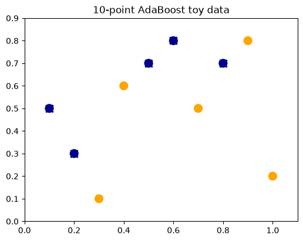

```python
x1 = np.arange(0.1, 1.01, 0.1)
x2 = np.array([0.5, 0.3, 0.1, 0.6, 0.7, 0.8, 0.5, 0.7, 0.8, 0.2])
y = np.array([1, 1, -1, -1, 1, 1, -1, 1, -1, -1])
X10 = np.column_stack([x1, x2])

xx, yy = np.meshgrid(np.linspace(0, 1.1, 220), np.linspace(0, 0.9, 180))
grid = np.column_stack([xx.ravel(), yy.ravel()])

def show_points(ax, weights=None):
    s = 80 if weights is None else 4000 * np.asarray(weights)
    ax.scatter(
        X10[:, 0], X10[:, 1],
        c=np.where(y > 0, "darkblue", "orange"),
        marker="o", s=s,
        linewidths=2,
        edgecolors=np.where(y > 0, "darkblue", "orange"),
    )
    pos = y > 0
    ax.scatter(X10[pos, 0], X10[pos, 1], marker="x", s=s[pos] if weights is not None else 80,
               c="darkblue", linewidths=2)
    ax.set_xlim(0, 1.1)
    ax.set_ylim(0, 0.9)

fig, ax = plt.subplots()
show_points(ax)
ax.set_title("10-point AdaBoost toy data")
plt.show()
```

```python
def stump_predict(grid, kind):
    g = np.asarray(grid)
    if kind == "x1_lt_0.25":
        return np.where(g[:, 0] < 0.25, 1, -1)
    if kind == "x2_gt_0.65":
        return np.where(g[:, 1] > 0.65, 1, -1)
    if kind == "x1_lt_0.85":
        return np.where(g[:, 0] < 0.85, 1, -1)
    raise ValueError(kind)

w = np.full(10, 1 / 10)
stumps = ["x1_lt_0.25", "x2_gt_0.65", "x1_lt_0.85"]
alphas = []
weight_hist = [w.copy()]

for kind in stumps:
    pred = stump_predict(X10, kind)
    err = np.sum(w * (pred != y))
    err = np.clip(err, 1e-12, 1 - 1e-12)
    a = 0.5 * np.log((1 - err) / err)
    alphas.append(a)
    w = w * np.exp(-a * y * pred)
    w = w / w.sum()
    weight_hist.append(w.copy())
    print(f"{kind:16s}  eps={err:.3f}  alpha={a:.4f}")

print("F3(x) = " + " + ".join(f"{a:.4f} f{i+1}(x)" for i, a in enumerate(alphas)))
```

```
x1_lt_0.25        eps=0.300  alpha=0.4236
x2_gt_0.65        eps=0.214  alpha=0.6496
x1_lt_0.85        eps=0.136  alpha=0.9229
F3(x) = 0.4236 f1(x) + 0.6496 f2(x) + 0.9229 f3(x)
```

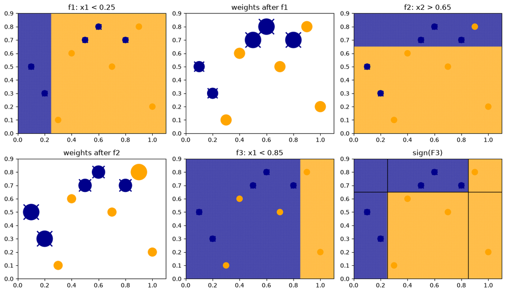

```python
fig, axes = plt.subplots(2, 3, figsize=(12, 7))
panels = [
    (axes[0, 0], "f1: x1 < 0.25", "x1_lt_0.25", weight_hist[0], False),
    (axes[0, 1], "weights after f1", None, weight_hist[1], False),
    (axes[0, 2], "f2: x2 > 0.65", "x2_gt_0.65", weight_hist[1], False),
    (axes[1, 0], "weights after f2", None, weight_hist[2], False),
    (axes[1, 1], "f3: x1 < 0.85", "x1_lt_0.85", weight_hist[2], False),
    (axes[1, 2], "sign(F3)", "final", weight_hist[0], True),
]

for ax, title, kind, wcur, is_final in panels:
    if kind == "final":
        F = (alphas[0] * stump_predict(grid, stumps[0])
             + alphas[1] * stump_predict(grid, stumps[1])
             + alphas[2] * stump_predict(grid, stumps[2]))
        ax.scatter(grid[:, 0], grid[:, 1], c=np.where(F > 0, "darkblue", "orange"),
                   s=1, alpha=0.35)
        ax.axvline(0.25, color="black", lw=1)
        ax.axhline(0.65, color="black", lw=1)
        ax.axvline(0.85, color="black", lw=1)
        show_points(ax)
    elif kind is not None:
        pred = stump_predict(grid, kind)
        ax.scatter(grid[:, 0], grid[:, 1], c=np.where(pred > 0, "darkblue", "orange"),
                   s=1, alpha=0.35)
        show_points(ax)
    else:
        show_points(ax, weights=wcur)
    ax.set_title(title)
    ax.set_xlim(0, 1.1)
    ax.set_ylim(0, 0.9)
plt.tight_layout()
plt.show()
```

Same 10 points with `sklearn.ensemble.AdaBoostClassifier` (stumps, 3 rounds). Split locations need not match the hand calculation; the algorithm is the same.

```python
ada = AdaBoostClassifier(
    estimator=DecisionTreeClassifier(max_depth=1, min_samples_leaf=1),
    n_estimators=3,
    learning_rate=1.0,
    random_state=0,
)
# sklearn wants {0,1} here
ada.fit(X10, (y == 1).astype(int))
print("estimator weights (alpha-like):", np.round(ada.estimator_weights_, 4))
print("estimator errors:", np.round(ada.estimator_errors_, 4))
```

```
estimator weights (alpha-like): [0.8473 1.2993 1.8458]
estimator errors: [0.3    0.2143 0.1364]
```

## AdaBoost / gradient boosting on a 1-d probability curve

R used `gbm(..., distribution="adaboost")` and plotted $1/(1+e^{-2F})$ at selected iteration counts.

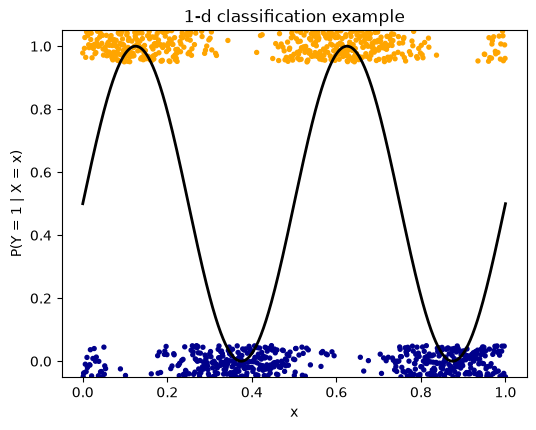

```
AdaBoostClassifier(estimator=DecisionTreeClassifier(max_depth=1,
                                                    min_samples_leaf=2),
                   n_estimators=200, random_state=1)
```

```python
rng = np.random.default_rng(1)
n = 1000
x = np.column_stack([np.linspace(0, 1, n), rng.uniform(0, 1, n)])
py = (np.sin(4 * np.pi * x[:, 0]) + 1) / 2
y1d = rng.binomial(1, py)

plt.scatter(x[:, 0], y1d + rng.uniform(-0.05, 0.05, n),
            s=8, c=np.where(y1d == 1, "orange", "darkblue"))
plt.plot(x[:, 0], py, color="black", lw=2)
plt.ylim(-0.05, 1.05)
plt.xlabel("x")
plt.ylabel("P(Y = 1 | X = x)")
plt.title("1-d classification example")
plt.show()

ada1d = AdaBoostClassifier(
    estimator=DecisionTreeClassifier(max_depth=1, min_samples_leaf=2),
    n_estimators=200,
    learning_rate=1.0,
    random_state=1,
)
ada1d.fit(x, y1d)
```

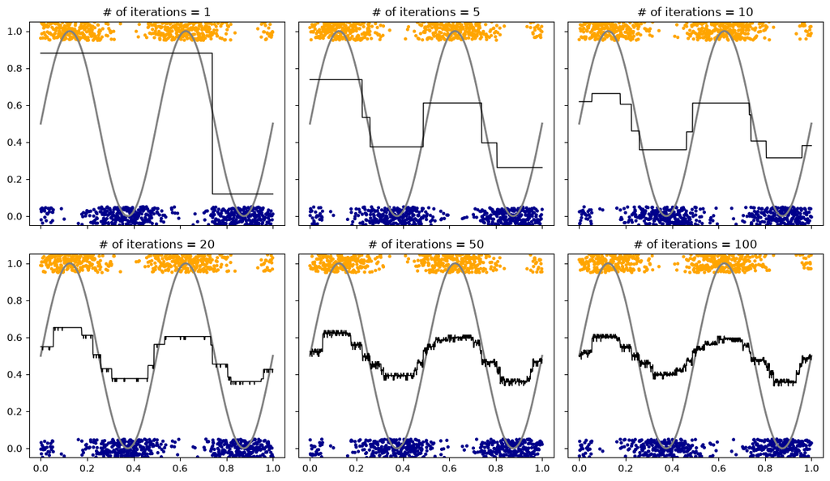

```python
sizes = [1, 5, 10, 20, 50, 100]
fig, axes = plt.subplots(2, 3, figsize=(12, 7), sharex=True, sharey=True)
for ax, m in zip(axes.ravel(), sizes):
    # Use the first m staged probability estimates
    proba = None
    for i, pr in enumerate(ada1d.staged_predict_proba(x), start=1):
        if i == m:
            proba = pr[:, 1]
            break
    ax.plot(x[:, 0], py, color="gray", lw=2)
    ax.scatter(x[:, 0], y1d + rng.uniform(-0.05, 0.05, n),
               s=6, c=np.where(y1d == 1, "orange", "darkblue"))
    ax.plot(x[:, 0], proba, color="black", lw=1)
    ax.set_title(f"# of iterations = {m}")
    ax.set_ylim(-0.05, 1.05)
plt.tight_layout()
plt.show()
```

`GradientBoostingClassifier` is the closer analogue of `gbm` with `distribution = "bernoulli"`. `staged_predict_proba` plays the role of `predict(..., n.trees = k)`. There is no `gbm.perf`; pick (T) with a validation curve or `validation_fraction` + `n_iter_no_change`.

```python
gb = GradientBoostingClassifier(
    loss="log_loss",
    n_estimators=200,
    learning_rate=1.0,   # large, as in the R notes, to make stages visible
    min_samples_leaf=2,
    subsample=0.8,
    validation_fraction=0.2,
    n_iter_no_change=20,
    random_state=1,
)
gb.fit(x, y1d)
print("trees used (early stopping may cut this):", gb.n_estimators_)
```

```
trees used (early stopping may cut this): 21
```

## xgboost

Same regression illustration as the R chunk. This cell uses `xgboost` when it loads, and sklearn otherwise.

For classification with xgboost set `objective` to `binary:logistic` or `multi:softprob`.

```python
rng = np.random.default_rng(2025)
n, p = 2000, 15
X = rng.normal(size=(n, p))

def f_true(X):
    return 2 * np.sin(X[:, 0]) + 0.5 * X[:, 1]**2 - 1.5 * (X[:, 2] > 0)

y = f_true(X) + rng.normal(scale=1.0, size=n)
idx = rng.choice(n, size=int(0.7 * n), replace=False)
mask = np.zeros(n, dtype=bool)
mask[idx] = True

if HAS_XGBOOST:
    dtrain = xgb.DMatrix(X[mask], label=y[mask], feature_names=[f"x{i+1}" for i in range(p)])
    dvalid = xgb.DMatrix(X[~mask], label=y[~mask], feature_names=[f"x{i+1}" for i in range(p)])
    params = {
        "objective": "reg:squarederror",
        "eval_metric": "rmse",
        "eta": 0.05,
        "max_depth": 4,
        "subsample": 0.8,
        "colsample_bytree": 0.8,
        "min_child_weight": 5,
        "lambda": 1.0,
        "alpha": 0.0,
    }
    fit = xgb.train(
        params=params,
        dtrain=dtrain,
        num_boost_round=3000,
        evals=[(dtrain, "train"), (dvalid, "valid")],
        early_stopping_rounds=50,
        verbose_eval=False,
    )
    print("Backend: xgboost")
    print("Best iteration:", fit.best_iteration, "  Valid RMSE:", round(fit.best_score, 4))
    imp = fit.get_score(importance_type="gain")
    imp_df = (pd.DataFrame({"feature": list(imp), "gain": list(imp.values())})
              .sort_values("gain", ascending=False))
    print(imp_df.head(8))
    pred = fit.predict(dvalid)
else:
    gbr = GradientBoostingRegressor(
        n_estimators=400,
        learning_rate=0.05,
        max_depth=4,
        subsample=0.8,
        min_samples_leaf=5,
        random_state=2025,
    )
    gbr.fit(X[mask], y[mask])
    pred = gbr.predict(X[~mask])
    print("Backend: sklearn GradientBoostingRegressor (xgboost/OpenMP unavailable)")
    imp_df = (pd.DataFrame({
        "feature": [f"x{i+1}" for i in range(p)],
        "gain": gbr.feature_importances_,
    }).sort_values("gain", ascending=False))
    print(imp_df.head(8))

rmse = np.sqrt(np.mean((pred - y[~mask])**2))
print("RMSE:", round(rmse, 4))
```

```
Backend: sklearn GradientBoostingRegressor (xgboost/OpenMP unavailable)
   feature      gain
0       x1  0.469687
2       x3  0.168983
1       x2  0.165296
7       x8  0.020251
4       x5  0.019769
14     x15  0.017333
5       x6  0.016234
12     x13  0.016091
RMSE: 1.0656
```

## Controlled Comparison: CART, Bagging, Forest, Boosting

Same circular Bayes rule, one training draw, one test draw. R used `cp` from `xerror`, `nbagg=200`, `mtry=1`, and `gbm` with 5-fold CV. Here $T$ for boosting uses `validation_fraction` + early stopping.

```python
def sim_circle(n, rng):
    x1 = rng.uniform(-1, 1, n)
    x2 = rng.uniform(-1, 1, n)
    p = np.where(x1**2 + x2**2 < 0.6, 0.9, 0.1)
    y = rng.binomial(1, p)
    return np.column_stack([x1, x2]), y

rng = np.random.default_rng(10)
n = 1000
Xtr, ytr = sim_circle(n, rng)
Xte, yte = sim_circle(n, rng)
bayes_te = (Xte[:, 0]**2 + Xte[:, 1]**2 < 0.6).astype(int)

# 1. Pruned CART: choose ccp_alpha by a small validation split (stand-in for rpart xerror)
X_in, X_val, y_in, y_val = train_test_split(Xtr, ytr, test_size=0.3, random_state=10)
base = DecisionTreeClassifier(random_state=10)
path = base.cost_complexity_pruning_path(X_in, y_in)
best_alpha, best_err = 0.0, 1.0
for a in path.ccp_alphas:
    t = DecisionTreeClassifier(random_state=10, ccp_alpha=a)
    t.fit(X_in, y_in)
    err = 1 - accuracy_score(y_val, t.predict(X_val))
    if err <= best_err:
        best_err, best_alpha = err, a
cart = DecisionTreeClassifier(random_state=10, ccp_alpha=best_alpha).fit(Xtr, ytr)

# 2. Bagging
bag = BaggingClassifier(
    estimator=DecisionTreeClassifier(),
    n_estimators=200,
    random_state=10,
).fit(Xtr, ytr)

# 3. Forest, classification default max_features = sqrt(p) = 1 when p = 2
rf = RandomForestClassifier(
    n_estimators=500,
    max_features=1,
    oob_score=True,
    random_state=10,
    n_jobs=-1,
).fit(Xtr, ytr)

# 4. Gradient boosting; T from internal validation
boost = GradientBoostingClassifier(
    loss="log_loss",
    n_estimators=400,
    learning_rate=0.05,
    max_depth=2,            # interaction.depth = 2
    subsample=0.8,
    validation_fraction=0.2,
    n_iter_no_change=20,
    random_state=10,
).fit(Xtr, ytr)

print("CART ccp_alpha:", round(best_alpha, 5))
print("Forest OOB error:", round(1 - rf.oob_score_, 4))
print("Boosting trees used:", boost.n_estimators_)
```

```
CART ccp_alpha: 0.00408
Forest OOB error: 0.119
Boosting trees used: 180
```

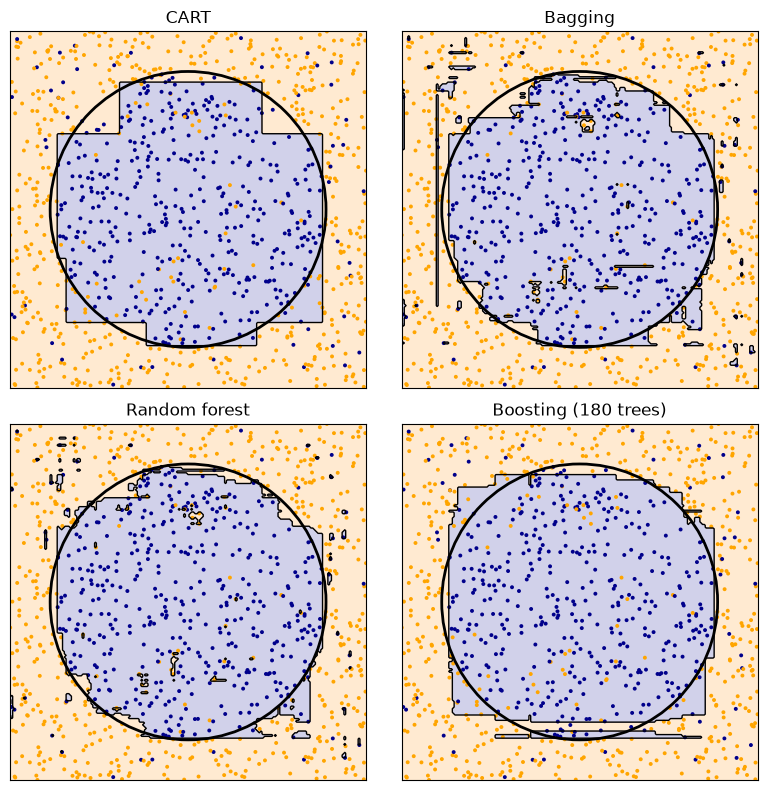

```python
models = {
    "CART": cart,
    "Bagging": bag,
    "Random forest": rf,
    f"Boosting ({boost.n_estimators_} trees)": boost,
}

fig, axes = plt.subplots(2, 2, figsize=(8, 8))
for ax, (name, model) in zip(axes.ravel(), models.items()):
    decision_boundary(ax, model.predict, (-1, 1), (-1, 1), n=201)
    ax.scatter(Xtr[:, 0], Xtr[:, 1],
               c=np.where(ytr == 1, "darkblue", "orange"),
               s=8, edgecolors="none")
    ax.add_patch(plt.Circle((0, 0), np.sqrt(0.6), fill=False, lw=2, color="black"))
    ax.set_title(name)
    ax.set_xticks([])
    ax.set_yticks([])
    ax.set_aspect("equal", "box")
plt.tight_layout()
plt.show()
```

```python
maj = int(np.bincount(ytr).argmax())
preds = {
    "Majority": np.full(len(yte), maj),
    "CART": cart.predict(Xte),
    "Bagging": bag.predict(Xte),
    "Forest": rf.predict(Xte),
    "Boosting": boost.predict(Xte),
}
rows = []
for name, ph in preds.items():
    rows.append({
        "method": name,
        "test_error": round(np.mean(ph != yte), 3),
        "agree_with_Bayes": round(np.mean(ph == bayes_te), 3),
    })
pd.DataFrame(rows)
```

|  | method | test_error | agree_with_Bayes |
| --- | --- | --- | --- |
| 0 | Majority | 0.496 | 0.507 |
| 1 | CART | 0.126 | 0.949 |
| 2 | Bagging | 0.123 | 0.954 |
| 3 | Forest | 0.119 | 0.962 |
| 4 | Boosting | 0.133 | 0.948 |